# How to Read a Residual Semivariogram

A Visual Guide for Longitudinal Model Diagnostics

## 1. What is a Semivariogram?

A **semivariogram** measures how different pairs of residuals become as the time lag between them increases. It provides a “flipped view” of the residual autocorrelation function (ACF).

### The Formula

For residuals $e_t$ at time $t$, the semivariogram at lag $h$ is:

$$\gamma(h) = \frac{1}{2} \text{Var}\{e_t - e_{t+h}\}$$

This captures the average squared difference between residuals separated by lag $h$, scaled by $\frac{1}{2}$.

### Key Identity

For **normalized residuals** (standardized to have variance 1), there is a fundamental relationship:

$$\gamma(h) \approx 1 - \rho(h)$$

where $\rho(h)$ is the autocorrelation at lag $h$.

**Interpretation:**

- If $\rho(h) = 0$ (no correlation), then $\gamma(h) = 1$
- If $\rho(h) > 0$ (positive correlation), then $\gamma(h) < 1$
- If $\rho(h) < 0$ (negative correlation), then $\gamma(h) > 1$

This makes the semivariogram a **mirror image** of the ACF, flipped around the horizontal line at 1.

## 2. How to Read the Axes

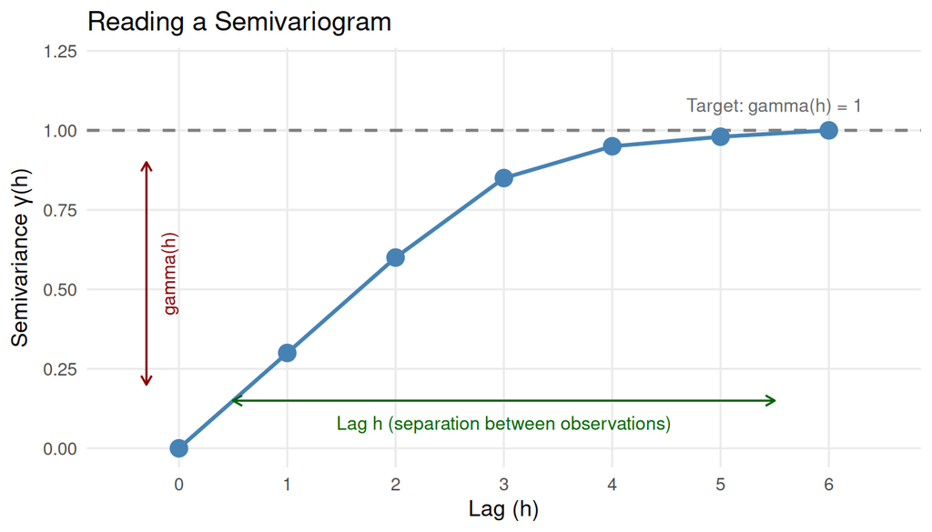

Figure 1: Anatomy of a semivariogram plot

```r
# Create demonstration data
demo_data <- data.frame(
  lag = 0:6,
  semivariance = c(0, 0.3, 0.6, 0.85, 0.95, 0.98, 1.0)
)

ggplot(demo_data, aes(x = lag, y = semivariance)) +

  geom_hline(yintercept = 1, linetype = "dashed", color = "gray50", linewidth = 0.8) +
  geom_point(size = 4, color = "steelblue") +
  geom_line(color = "steelblue", linewidth = 1) +
  annotate("text", x = 5.5, y = 1.08, label = "Target: gamma(h) = 1",
           color = "gray40", size = 3.5) +
  annotate("segment", x = 0.5, xend = 5.5, y = 0.15, yend = 0.15,
           arrow = arrow(length = unit(0.2, "cm"), ends = "both"),
           color = "darkgreen") +
  annotate("text", x = 3, y = 0.08, label = "Lag h (separation between observations)",
           color = "darkgreen", size = 3.5) +

annotate("segment", x = -0.3, xend = -0.3, y = 0.2, yend = 0.9,
           arrow = arrow(length = unit(0.2, "cm"), ends = "both"),
           color = "darkred") +
  annotate("text", x = -0.1, y = 0.55, label = "gamma(h)", angle = 90,
           color = "darkred", size = 3.5, hjust = 0.5) +
  scale_x_continuous(breaks = 0:6, limits = c(-0.5, 6.5)) +
  scale_y_continuous(limits = c(0, 1.2)) +
  labs(x = "Lag (h)",
       y = expression(paste("Semivariance ", gamma, "(h)")),
       title = "Reading a Semivariogram") +
  theme_minimal(base_size = 12) +
  theme(panel.grid.minor = element_blank())
```

### X-axis: Lag

- Represents the **separation** (in time units) between pairs of residuals
- Lag 1 = consecutive observations
- Lag 2 = observations two time points apart
- And so on…

### Y-axis: Semivariance

- The average squared difference between residual pairs at that lag, divided by 2
- For normalized residuals, values are centered around 1
- **Goal**: A flat line near 1 indicates the correlation structure is properly modeled

## 3. Pattern Interpretation Table

The following table summarizes common patterns you will encounter:

| Pattern | Visual Description | Meaning | Diagnosis |
| --- | --- | --- | --- |
| **Flat near 1** | Horizontal line at $\gamma \approx 1$ for all lags | No residual correlation | Good model fit |
| **Starts below 1, rises** | Curve begins low and increases toward 1 | Positive correlation remains in residuals | Need AR(1) or similar |
| **Above 1 at lag 1** | First point exceeds 1 | Negative correlation at lag 1 | Possible over-differencing or wrong structure |
| **Jump at zero lag** | Discontinuity at $h=0$ (nugget effect) | Measurement error or micro-scale variation | Consider nugget in spatial models |
| **Different levels by group** | Separate curves for different groups | Heteroskedasticity across groups | Add variance functions (e.g., `varIdent`) |

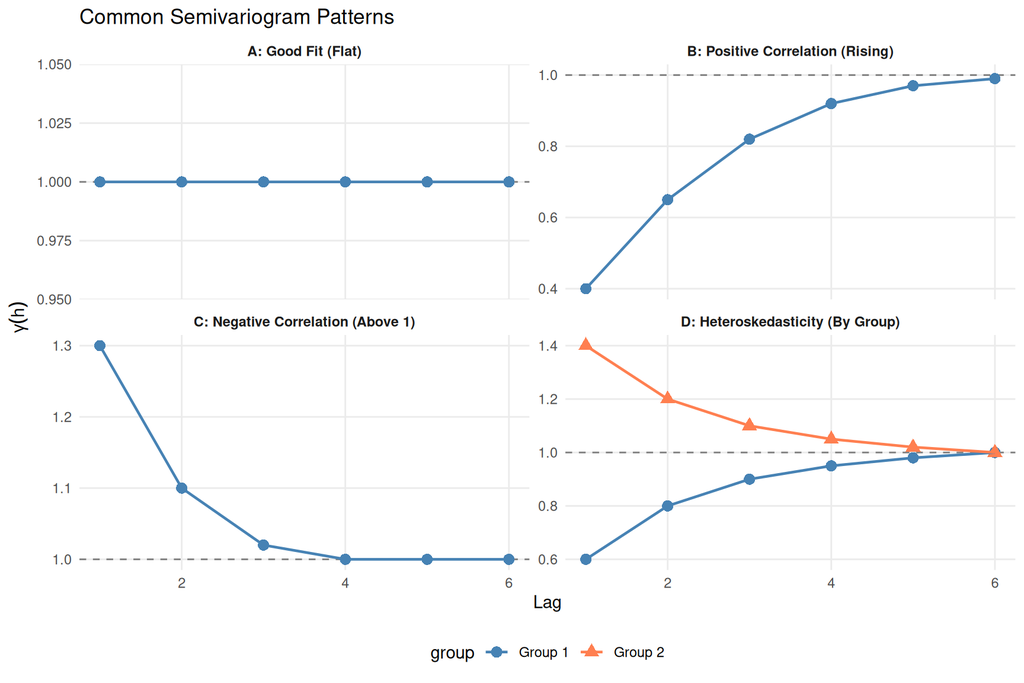

Figure 2: Common semivariogram patterns and their interpretations

```r
# Create example patterns
patterns <- data.frame(
  lag = rep(1:6, 4),
  pattern = rep(c("A: Good Fit (Flat)",
                  "B: Positive Correlation (Rising)",
                  "C: Negative Correlation (Above 1)",
                  "D: Heteroskedasticity (By Group)"), each = 6),
  semivariance = c(
    rep(1, 6),                              # Good fit
    c(0.4, 0.65, 0.82, 0.92, 0.97, 0.99),   # AR(1) not modeled
    c(1.3, 1.1, 1.02, 1.0, 1.0, 1.0),       # Negative correlation
    c(0.6, 0.8, 0.9, 0.95, 0.98, 1.0)       # One group example
  )
)

# Add second group for heteroskedasticity panel
patterns_hetero <- data.frame(
  lag = 1:6,
  pattern = rep("D: Heteroskedasticity (By Group)", 6),
  semivariance = c(1.4, 1.2, 1.1, 1.05, 1.02, 1.0),
  group = "Group 2"
)

patterns$group <- "Group 1"
patterns <- rbind(patterns, patterns_hetero)

ggplot(patterns, aes(x = lag, y = semivariance, color = group, shape = group)) +
  geom_hline(yintercept = 1, linetype = "dashed", color = "gray50") +
  geom_point(size = 3) +
  geom_line(linewidth = 0.8) +
  facet_wrap(~pattern, ncol = 2, scales = "free_y") +
  scale_color_manual(values = c("Group 1" = "steelblue", "Group 2" = "coral")) +
  labs(x = "Lag",
       y = expression(gamma(h)),
       title = "Common Semivariogram Patterns") +
  theme_minimal(base_size = 11) +
  theme(legend.position = "bottom",
        strip.text = element_text(face = "bold"),
        panel.grid.minor = element_blank())
```

## 4. Matching Covariance Models

When your semivariogram shows residual correlation, use this guide to select an appropriate covariance structure:

| Data Pattern | Semivariogram Shape | Suggested Model |
| --- | --- | --- |
| Independence assumption on correlated data | Rises steadily with lag | Any correlation structure |
| Correlation decays quickly | Quick rise, then plateau | AR(1): `corAR1()` |
| Smooth decay of correlation | Smooth exponential rise | Exponential: `corExp()` |
| Equal correlation at all lags | Constant for $h \geq 1$ | Compound Symmetry: `corCompSymm()` |
| Oscillating correlation | Wave pattern | Consider seasonal effects |
| Spatial-like decay | Gradual rise with distance | Gaussian: `corGaus()` or Spherical: `corSpher()` |

### Visual Guide to Covariance Structures

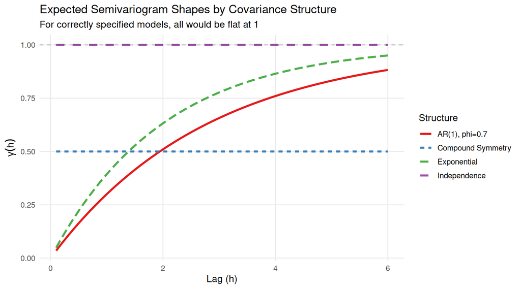

Figure 3: Semivariogram shapes for different covariance structures

```r
lag <- seq(0.1, 6, by = 0.1)

cov_shapes <- data.frame(
  lag = rep(lag, 4),
  Structure = rep(c("AR(1), phi=0.7", "Exponential",
                    "Compound Symmetry", "Independence"), each = length(lag)),
  gamma = c(
    1 - 0.7^lag,                           # AR(1)
    1 - exp(-lag/2),                       # Exponential
    c(rep(0.5, length(lag))),              # Compound symmetry (constant rho)
    rep(1, length(lag))                    # Independence
  )
)

ggplot(cov_shapes, aes(x = lag, y = gamma, color = Structure, linetype = Structure)) +
  geom_hline(yintercept = 1, linetype = "dashed", color = "gray70") +
  geom_line(linewidth = 1.2) +
  scale_color_brewer(palette = "Set1") +
  labs(x = "Lag (h)",
       y = expression(gamma(h)),
       title = "Expected Semivariogram Shapes by Covariance Structure",
       subtitle = "For correctly specified models, all would be flat at 1") +
  theme_minimal(base_size = 12) +
  theme(legend.position = "right",
        panel.grid.minor = element_blank())
```

## 5. Practical Workflow

Follow these steps when diagnosing correlation structure in your longitudinal model:

1. **Fit a candidate model**
   - Start with independence (no correlation structure)
   - Or fit your hypothesized correlation structure
2. **Extract normalized residuals**
   - Use `resid(model, type = "normalized")` in `nlme`
   - Normalized residuals should have variance 1 if model is correct
3. **Plot the semivariogram**
   - Use `nlme::Variogram()` with `resType = "normalized"`
   - Examine `gamma(h)` vs. lag
4. **Evaluate the plot**
   - **Goal**: Flat curve near 1 for all lags
   - Rising curve = positive correlation not captured
   - Values above 1 = negative correlation
5. **Compare models**
   - Fit alternative correlation structures
   - Choose the model with:
     - Flattest semivariogram (good correlation structure)
     - Reasonable AIC/BIC (model parsimony)

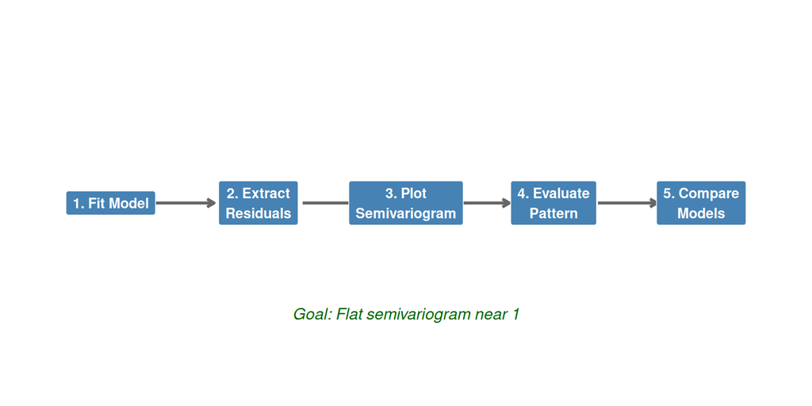

Figure 4: Decision flowchart for semivariogram diagnostics

## 6. Complete R Example

Let us work through a complete example: simulating AR(1) correlated data, fitting two models (Independence and AR(1)), and comparing their semivariograms.

### Step 1: Simulate AR(1) Data

```r
set.seed(667)

# Simulation parameters
n_subjects <- 50
n_times <- 8
phi <- 0.6  # AR(1) correlation parameter
sigma <- 2  # residual SD

# Create data structure
sim_data <- expand.grid(
  time = 1:n_times,
  subject = 1:n_subjects
) |>
  arrange(subject, time)

# Generate AR(1) correlated errors for each subject
generate_ar1_errors <- function(n, phi, sigma) {
  e <- numeric(n)
  e[1] <- rnorm(1, 0, sigma)
  for (t in 2:n) {
    e[t] <- phi * e[t-1] + rnorm(1, 0, sigma * sqrt(1 - phi^2))
  }
  return(e)
}

# Add random effects and AR(1) errors
sim_data <- sim_data |>
  group_by(subject) |>
  mutate(
    # Random intercept
    b0 = rnorm(1, 0, 3)[1],
    # AR(1) errors
    error = generate_ar1_errors(n(), phi, sigma),
    # Fixed effects: intercept + time effect
    y = 10 + 0.5 * time + b0 + error
  ) |>
  ungroup()

# Convert to appropriate types for nlme
sim_data$subject <- factor(sim_data$subject)

head(sim_data, 16)
```

```
# A tibble: 16 × 5
    time subject    b0  error     y
   <int> <fct>   <dbl>  <dbl> <dbl>
 1     1 1       -2.57 -3.10   4.83
 2     2 1       -2.57 -1.10   7.33
 3     3 1       -2.57 -0.954  7.98
 4     4 1       -2.57 -0.673  8.76
 5     5 1       -2.57 -0.285  9.65
 6     6 1       -2.57  2.22  12.6
 7     7 1       -2.57 -1.66   9.27
 8     8 1       -2.57 -0.867 10.6
 9     1 2        2.31  4.57  17.4
10     2 2        2.31  4.63  17.9
11     3 2        2.31  2.04  15.9
12     4 2        2.31  3.31  17.6
13     5 2        2.31  2.16  17.0
14     6 2        2.31  2.89  18.2
15     7 2        2.31  0.725 16.5
16     8 2        2.31  1.82  18.1
```

### Step 2: Fit Candidate Models

```r
# Model 1: Independence (ignoring correlation)
fit_indep <- lme(y ~ time,
                 random = ~ 1 | subject,
                 data = sim_data,
                 method = "REML")

# Model 2: AR(1) correlation structure
fit_ar1 <- lme(y ~ time,
               random = ~ 1 | subject,
               correlation = corAR1(form = ~ time | subject),
               data = sim_data,
               method = "REML")

# Compare model summaries
cat("=== Independence Model ===\n")
```

```
=== Independence Model ===
```

```r
summary(fit_indep)$tTable
```

```
                 Value  Std.Error  DF  t-value      p-value
(Intercept) 10.8189004 0.49674551 349 21.77956 5.042579e-67
time         0.4457152 0.03922881 349 11.36194 1.146226e-25
```

```r
cat("\n=== AR(1) Model ===\n")
```

```
=== AR(1) Model ===
```

```r
summary(fit_ar1)$tTable
```

```
                 Value  Std.Error  DF  t-value      p-value
(Intercept) 10.7764904 0.53848773 349 20.01251 6.927310e-60
time         0.4555996 0.05870259 349  7.76115 9.399093e-14
```

```r
cat("\nEstimated phi:", coef(fit_ar1$modelStruct$corStruct, unconstrained = FALSE))
```

```
Estimated phi: 0.587617
```

### Step 3: Extract Semivariograms

```r
# Compute semivariograms using normalized residuals
vario_indep <- Variogram(fit_indep, resType = "normalized", form = ~ time | subject)
vario_ar1 <- Variogram(fit_ar1, resType = "normalized", form = ~ time | subject)

# View the variogram data
cat("Independence Model Semivariogram:\n")
```

```
Independence Model Semivariogram:
```

```r
print(vario_indep)
```

```
     variog dist n.pairs
1 0.5755234    1     350
2 0.9270826    2     300
3 1.1779846    3     250
4 1.2980102    4     200
5 1.2571720    5     150
6 1.1336385    6     100
7 1.2080833    7      50
```

```r
cat("\nAR(1) Model Semivariogram:\n")
```

```
AR(1) Model Semivariogram:
```

```r
print(vario_ar1)
```

```
     variog dist n.pairs
1 1.0110411    1     350
2 0.9512497    2     300
3 1.0250936    3     250
4 1.0631181    4     200
5 0.9674607    5     150
6 0.9321511    6     100
7 0.8837251    7      50
```

### Step 4: Plot and Compare

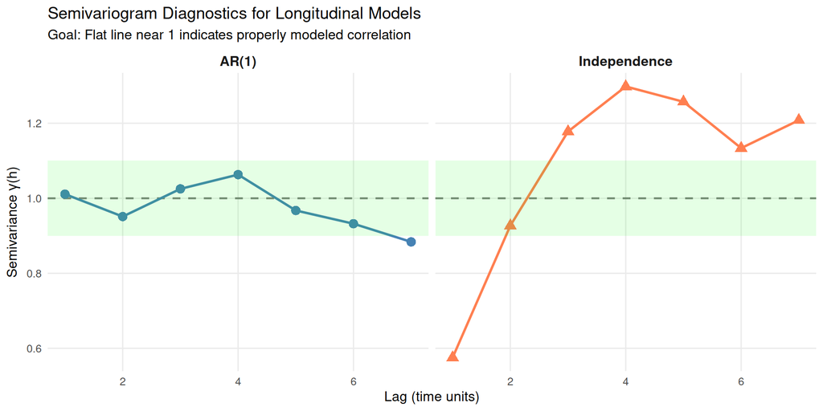

Figure 5: Semivariogram comparison: Independence vs. AR(1) model

```r
# Combine variogram data for plotting
vario_indep$Model <- "Independence"
vario_ar1$Model <- "AR(1)"

vario_combined <- rbind(
  data.frame(vario_indep),
  data.frame(vario_ar1)
)

# Create comparison plot
ggplot(vario_combined, aes(x = dist, y = variog)) +
  geom_hline(yintercept = 1, linetype = "dashed", color = "gray50", linewidth = 0.8) +
  geom_point(aes(color = Model, shape = Model), size = 3.5) +
  geom_line(aes(color = Model, group = Model), linewidth = 1) +
  facet_wrap(~Model) +
  scale_color_manual(values = c("Independence" = "coral", "AR(1)" = "steelblue")) +
  scale_shape_manual(values = c("Independence" = 17, "AR(1)" = 16)) +
  labs(x = "Lag (time units)",
       y = expression(paste("Semivariance ", gamma, "(h)")),
       title = "Semivariogram Diagnostics for Longitudinal Models",
       subtitle = "Goal: Flat line near 1 indicates properly modeled correlation") +
  theme_minimal(base_size = 12) +
  theme(legend.position = "none",
        strip.text = element_text(face = "bold", size = 12),
        panel.grid.minor = element_blank()) +
  annotate("rect", xmin = -Inf, xmax = Inf, ymin = 0.9, ymax = 1.1,
           alpha = 0.1, fill = "green")
```

### Interpretation

```r
# Calculate mean deviation from 1
mean_dev_indep <- mean(abs(vario_indep$variog - 1))
mean_dev_ar1 <- mean(abs(vario_ar1$variog - 1))

cat("Mean absolute deviation from 1:\n")
```

```
Mean absolute deviation from 1:
```

```r
cat("  Independence model:", round(mean_dev_indep, 3), "\n")
```

```
  Independence model: 0.225
```

```r
cat("  AR(1) model:", round(mean_dev_ar1, 3), "\n\n")
```

```
  AR(1) model: 0.052
```

```r
# Model comparison
cat("Model Comparison:\n")
```

```
Model Comparison:
```

```r
cat("  Independence AIC:", round(AIC(fit_indep), 2), "\n")
```

```
  Independence AIC: 1778.89
```

```r
cat("  AR(1) AIC:", round(AIC(fit_ar1), 2), "\n")
```

```
  AR(1) AIC: 1698.49
```

```r
cat("  Difference:", round(AIC(fit_indep) - AIC(fit_ar1), 2),
    "(positive = AR(1) preferred)\n")
```

```
  Difference: 80.4 (positive = AR(1) preferred)
```

## Summary

The residual semivariogram is a powerful diagnostic tool for longitudinal data analysis:

- **Plot** $\gamma(h)$ vs. lag $h$ for normalized residuals
- **Look for** a flat line near 1
- **Rising curves** indicate unmodeled positive correlation
- **Values above 1** suggest negative correlation or model misspecification
- **Compare models** using both semivariogram patterns and information criteria

When in doubt, always examine the semivariogram before finalizing your correlation structure choice.